# Chiara homework week 10 day 2

# MPV

```r
library(tidyverse)
library(janitor)
library(GGally)
```

## 1. Load the housing_prices.csv data set and undertake an initial exploration of the data. You will find details on the data set on the relevant Kaggle page

```r
housing_prices <- read_csv("data/housing_prices.csv") %>%
  clean_names()
```

```r
glimpse(housing_prices)
```

```
Rows: 19,675
Columns: 10
$ longitude          <dbl> -122.23, -122.22, -122.24, -122.25, -122.25, -122.25, -122.25, -122.25, -122.26, -122.25, -122.26, -122.26, -122.…
$ latitude           <dbl> 37.88, 37.86, 37.85, 37.85, 37.85, 37.85, 37.84, 37.84, 37.84, 37.84, 37.85, 37.85, 37.85, 37.84, 37.85, 37.85, 3…
$ housing_median_age <dbl> 41, 21, 52, 52, 52, 52, 52, 52, 42, 52, 52, 52, 52, 52, 52, 50, 52, 52, 50, 52, 40, 42, 52, 52, 52, 41, 49, 52, 5…
$ total_rooms        <dbl> 880, 7099, 1467, 1274, 1627, 919, 2535, 3104, 2555, 3549, 2202, 3503, 2491, 696, 2643, 1120, 1966, 1228, 2239, 15…
$ total_bedrooms     <dbl> 129, 1106, 190, 235, 280, 213, 489, 687, 665, 707, 434, 752, 474, 191, 626, 283, 347, 293, 455, 298, 184, 367, 54…
$ population         <dbl> 322, 2401, 496, 558, 565, 413, 1094, 1157, 1206, 1551, 910, 1504, 1098, 345, 1212, 697, 793, 648, 990, 690, 409, …
$ households         <dbl> 126, 1138, 177, 219, 259, 193, 514, 647, 595, 714, 402, 734, 468, 174, 620, 264, 331, 303, 419, 275, 166, 366, 47…
$ median_income      <dbl> 8.3252, 8.3014, 7.2574, 5.6431, 3.8462, 4.0368, 3.6591, 3.1200, 2.0804, 3.6912, 3.2031, 3.2705, 3.0750, 2.6736, 1…
$ median_house_value <dbl> 452600, 358500, 352100, 341300, 342200, 269700, 299200, 241400, 226700, 261100, 281500, 241800, 213500, 191300, 1…
$ ocean_proximity    <chr> "NEAR BAY", "NEAR BAY", "NEAR BAY", "NEAR BAY", "NEAR BAY", "NEAR BAY", "NEAR BAY", "NEAR BAY", "NEAR BAY", "NEAR…
```

##2. We expect the total_rooms of houses to be strongly correlated with total_bedrooms. Use ggpairs() to investigate correlations between these two variables.

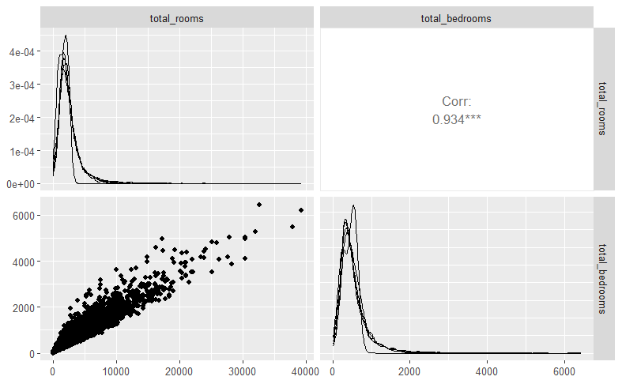

```r
housing_prices %>%
  select(total_rooms, total_bedrooms) %>%
ggpairs(housing_prices, progress = FALSE)
```

Both from the correlation number and from the scatter plot we can deduce that the two variables are strongly correlated.

## 3. So, we do find significant correlations. Let’s drop total_bedrooms from the dataset, and use only total_rooms going forward.

```r
housing_prices <- housing_prices %>%
  select(-total_bedrooms)

housing_prices
```

| longitude | latitude | housing_median_age | total_rooms | population | households | median_income | median_house_value | ocean_proximity |
| --- | --- | --- | --- | --- | --- | --- | --- | --- |
| -122.23 | 37.88 | 41 | 880 | 322 | 126 | 8.3252 | 452600 | NEAR BAY |
| -122.22 | 37.86 | 21 | 7099 | 2401 | 1138 | 8.3014 | 358500 | NEAR BAY |
| -122.24 | 37.85 | 52 | 1467 | 496 | 177 | 7.2574 | 352100 | NEAR BAY |
| -122.25 | 37.85 | 52 | 1274 | 558 | 219 | 5.6431 | 341300 | NEAR BAY |
| -122.25 | 37.85 | 52 | 1627 | 565 | 259 | 3.8462 | 342200 | NEAR BAY |
| -122.25 | 37.85 | 52 | 919 | 413 | 193 | 4.0368 | 269700 | NEAR BAY |
| -122.25 | 37.84 | 52 | 2535 | 1094 | 514 | 3.6591 | 299200 | NEAR BAY |
| -122.25 | 37.84 | 52 | 3104 | 1157 | 647 | 3.1200 | 241400 | NEAR BAY |
| -122.26 | 37.84 | 42 | 2555 | 1206 | 595 | 2.0804 | 226700 | NEAR BAY |
| -122.25 | 37.84 | 52 | 3549 | 1551 | 714 | 3.6912 | 261100 | NEAR BAY |

[output cut: 990 more lines]

## 4. We are interested in developing a regression model for the median_house_value of a house in terms of the possible predictor variables in the dataset.

- Use ggpairs() to investigate correlations between median_house_value and the predictors (this may take a while to run, don’t worry, make coffee or something).

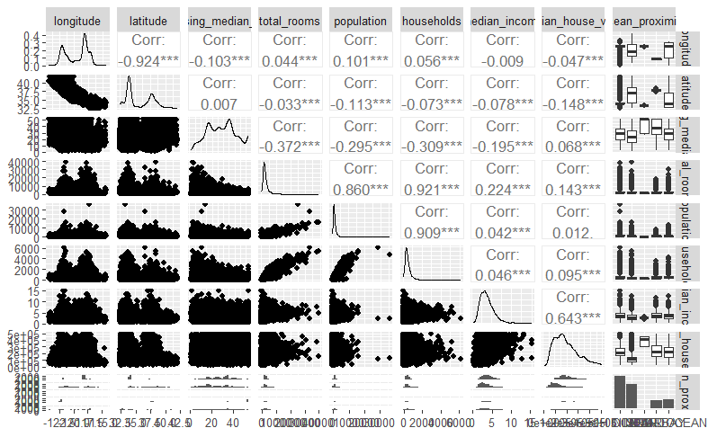

```r
ggpairs(housing_prices, progress = FALSE)
```

It seems that there is a medium correlation between ‘median_house_value’ and ‘median_income’.

- Perform further ggplot visualisations of any significant correlations you find.

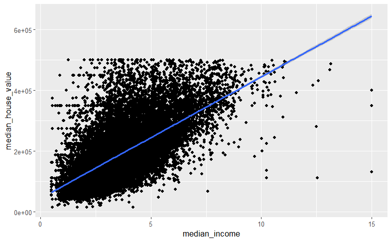

```r
housing_prices %>%
  ggplot(aes(x = median_income, y = median_house_value))+
  geom_point()+
  geom_smooth(method = 'lm')
```

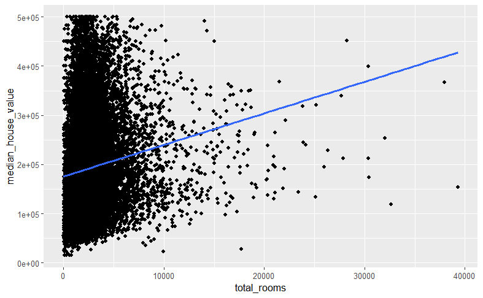

```r
housing_prices %>%
  ggplot(aes(x = total_rooms, y = median_house_value))+
  geom_point()+
  geom_smooth(method = 'lm', se = FALSE)
```

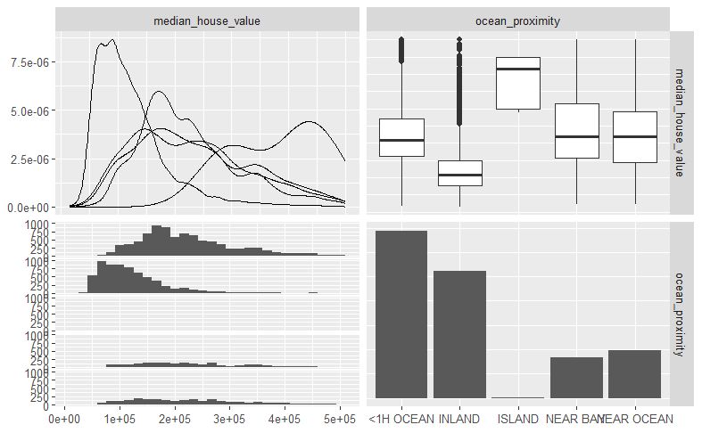

```r
housing_prices %>%
  select(median_house_value, ocean_proximity) %>%
  ggpairs(housing_prices, progress = FALSE)
```

## 5. Shortly we may try a regression model to fit the categorical predictor ocean_proximity. Investigate the level of ocean_proximity predictors. How many dummy variables do you expect to get from it?

```r
housing_prices %>%
  distinct(ocean_proximity)
```

| ocean_proximity |
| --- |
| NEAR BAY |
| <1H OCEAN |
| INLAND |
| NEAR OCEAN |
| ISLAND |

## 6. Start with simple linear regression. Regress median_house_value on median_income and check the regression diagnostics.

```r
model <- lm(median_house_value ~ median_income, housing_prices)

model
```

```
Call:
lm(formula = median_house_value ~ median_income, data = housing_prices)

Coefficients:
  (Intercept)  median_income
        45457          39987
```

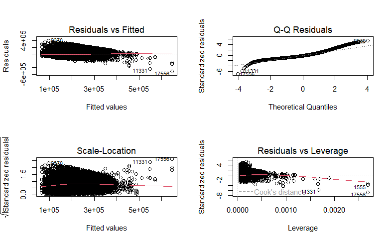

```r
par(mfrow = c(2,2))
plot(model)
```

```r
summary(model)
```

```
Call:
lm(formula = median_house_value ~ median_income, data = housing_prices)

Residuals:
    Min      1Q  Median      3Q     Max
-513966  -51564  -13979   36549  403935

Coefficients:
              Estimate Std. Error t value Pr(>|t|)
(Intercept)    45457.0     1359.0   33.45   <2e-16 ***
median_income  39987.0      339.9  117.64   <2e-16 ***
---
Signif. codes:  0 ‘***’ 0.001 ‘**’ 0.01 ‘*’ 0.05 ‘.’ 0.1 ‘ ’ 1

Residual standard error: 74870 on 19673 degrees of freedom
Multiple R-squared:  0.4129,    Adjusted R-squared:  0.4129
F-statistic: 1.384e+04 on 1 and 19673 DF,  p-value: < 2.2e-16
```

```r
library(modelr)
sample <- housing_prices %>%
  add_predictions(model) %>%
  add_residuals(model)
sample
```

| longitude | latitude | housing_median_age | total_rooms | population | households | median_income | median_house_value | ocean_proximity | pred | resid |
| --- | --- | --- | --- | --- | --- | --- | --- | --- | --- | --- |
| -122.23 | 37.88 | 41 | 880 | 322 | 126 | 8.3252 | 452600 | NEAR BAY | 378356.87 | 74243.13040 |
| -122.22 | 37.86 | 21 | 7099 | 2401 | 1138 | 8.3014 | 358500 | NEAR BAY | 377405.18 | -18905.17872 |
| -122.24 | 37.85 | 52 | 1467 | 496 | 177 | 7.2574 | 352100 | NEAR BAY | 335658.74 | 16441.26188 |
| -122.25 | 37.85 | 52 | 1274 | 558 | 219 | 5.6431 | 341300 | NEAR BAY | 271107.70 | 70192.29545 |
| -122.25 | 37.85 | 52 | 1627 | 565 | 259 | 3.8462 | 342200 | NEAR BAY | 199255.04 | 142944.95742 |
| -122.25 | 37.85 | 52 | 919 | 413 | 193 | 4.0368 | 269700 | NEAR BAY | 206876.57 | 62823.43292 |
| -122.25 | 37.84 | 52 | 2535 | 1094 | 514 | 3.6591 | 299200 | NEAR BAY | 191773.47 | 107426.52738 |
| -122.25 | 37.84 | 52 | 3104 | 1157 | 647 | 3.1200 | 241400 | NEAR BAY | 170216.47 | 71183.52558 |
| -122.26 | 37.84 | 42 | 2555 | 1206 | 595 | 2.0804 | 226700 | NEAR BAY | 128645.98 | 98054.02332 |
| -122.25 | 37.84 | 52 | 3549 | 1551 | 714 | 3.6912 | 261100 | NEAR BAY | 193057.06 | 68042.94429 |

[output cut: 990 more lines]

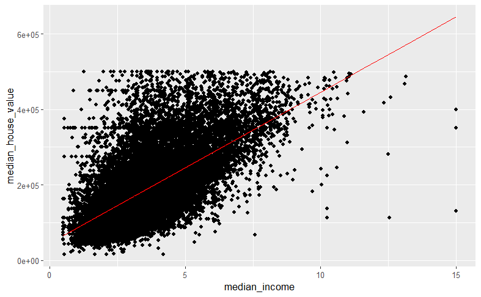

```r
sample %>%
  ggplot(aes(x = median_income)) +
  geom_point(aes(y = median_house_value)) +
  geom_line(aes(y = pred), col = "red")
```

## 7. Add another predictor of your choice. Check your assumptions, diagnostics, and interpret the model.

```r
model_2 <- lm(median_house_value ~ median_income + ocean_proximity, housing_prices)

model_2
```

```
Call:
lm(formula = median_house_value ~ median_income + ocean_proximity,
    data = housing_prices)

Coefficients:
              (Intercept)              median_income      ocean_proximityINLAND      ocean_proximityISLAND    ocean_proximityNEAR BAY
                    83581                      35118                     -72314                     200480                      16630
ocean_proximityNEAR OCEAN
                    15553
```

```r
summary(model_2)
```

```
Call:
lm(formula = median_house_value ~ median_income + ocean_proximity,
    data = housing_prices)

Residuals:
    Min      1Q  Median      3Q     Max
-479055  -41086  -11143   27912  376647

Coefficients:
                          Estimate Std. Error t value Pr(>|t|)
(Intercept)                83581.2     1407.7  59.373  < 2e-16 ***
median_income              35118.0      304.8 115.223  < 2e-16 ***
ocean_proximityINLAND     -72313.7     1100.7 -65.695  < 2e-16 ***
ocean_proximityISLAND     200480.2    29232.9   6.858 7.19e-12 ***
ocean_proximityNEAR BAY    16629.7     1591.9  10.446  < 2e-16 ***
ocean_proximityNEAR OCEAN  15552.9     1500.8  10.363  < 2e-16 ***
---
Signif. codes:  0 ‘***’ 0.001 ‘**’ 0.01 ‘*’ 0.05 ‘.’ 0.1 ‘ ’ 1

Residual standard error: 65340 on 19669 degrees of freedom
Multiple R-squared:  0.5529,    Adjusted R-squared:  0.5528
F-statistic:  4865 on 5 and 19669 DF,  p-value: < 2.2e-16
```

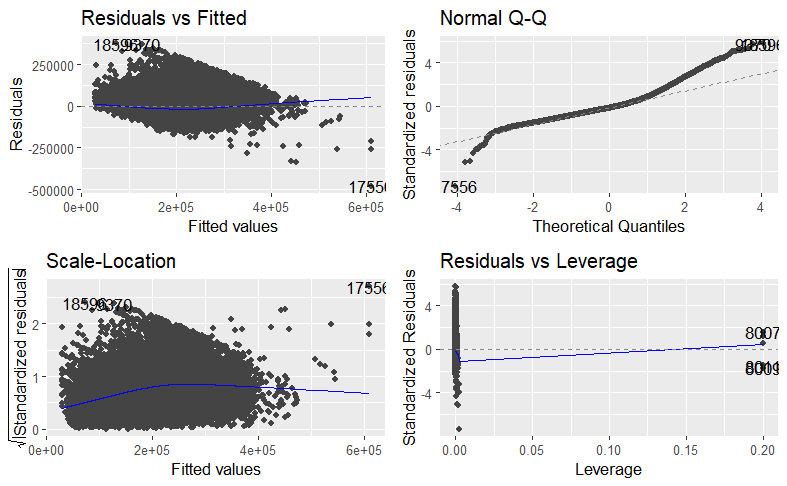

```r
autoplot(model_2)
```

## Correction:

The predictors median income and ocean_proximity explains 55% of the variation in the median_house_value. In addition, these predictors are also significant. For every increase in median income by 1 unit, the median house price increases by 35118.0 if all other predictors remain the same. If the house is on an island, the median house price increases by 200,480.2 if all other predictors remain the same.